# Final Project Written Report

## 2 Assessing the Linear Relationship

Now that we have our combined dataset, we can now assess the relationship between a country’s GDP per capita and the proportion of their population that has access to water. Before formally analyzing this relationship through a fitted linear regression model, we would like to look at the relationship between the two variables over time.

### 2.1 Data Visualization

```r
gdp_v_water |>
  ggplot(aes(x = gdp_pc,
             y = access_pct,
             fill = region,
             color = region,
             shape = region)
         ) +
  geom_point() +
  theme_bw() +
  scale_color_manual(values = c("#e66101",
                                "#fdb863",
                                "#b2abd2",
                                "#5e3c99")
                     )+
  scale_fill_manual(values = c("#e66101",
                                "#fdb863",
                                "#b2abd2",
                                "#5e3c99")
                     ) +
  scale_shape_manual(values = 21:24) +
  labs(x = "GDP Per Capita",
       y = "",
       subtitle = "% of Pop. with Basic Water Access",
       title = "Relationship between Water Access and GDP",
       tag = "Year: {frame_time}",
       fill = "World Region",
       color = "World Region",
       shape = "World Region"
       ) +
  transition_time(as.integer(year)) +
  ease_aes('linear')
```

[output not shown]

Because we can see that the relationship between GDP per capita and Water Access is far from being linear, we would like to perform a logit transformation on the average proportion of a country’s population that has basic water access (our response variable) before fitting a linear model to help with this issue of non-linearity using the following formula:

ln(*average water access* / (101 - *average water access*))

A plot containing a fitted linear model alongside our transformed response variable follows.

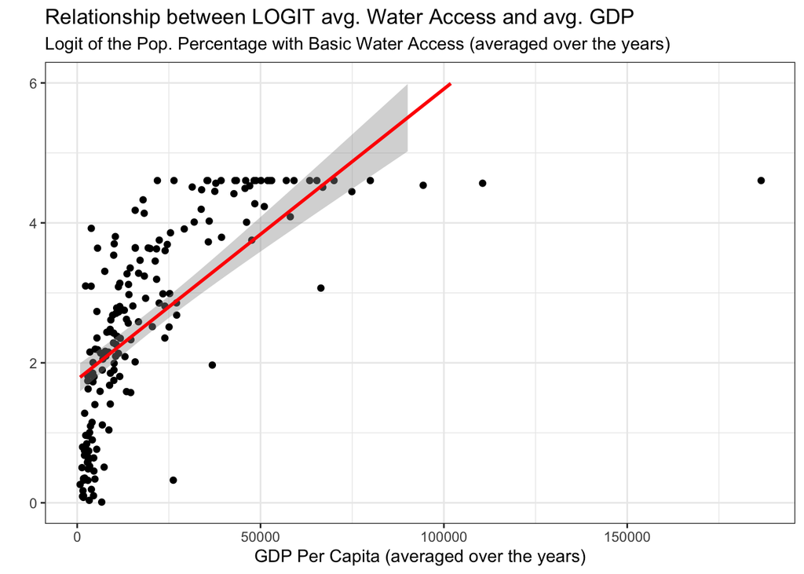

```r
gdp_v_water_mean <- gdp_v_water |>
  group_by(country, region) |>
  summarize(mean_gdp = mean(gdp_pc),
            mean_access = mean(access_pct)
            ) |>
  mutate(logit_meanaccess = log((mean_access)/(101 - mean_access)))

gdp_v_water_mean |>
  ggplot(aes(x = mean_gdp,
             y = logit_meanaccess
             )
         ) +
  geom_point() +
  geom_smooth(method = "lm",
              aes(x = mean_gdp,
                  y = logit_meanaccess,
                  group = 1),
              color = "red"
              ) +
  theme_bw() +
  labs(x = "GDP Per Capita (averaged over the years)",
       y = "",
       subtitle = "Logit of the Pop. Percentage with Basic Water Access (averaged over the years)",
       title = "Relationship between LOGIT avg. Water Access and avg. GDP"
       ) +
  scale_y_continuous(limits = c(0, 6))
```

From this plot, we can see that even with a transformation, there still seems to be a somewhat weak, positive linear relationship between the average GDP per capita of a country and the logit of the population percentage with access to a basic water source, though this relationship is much improved in terms of linearity over the relationship with the original non transformed response. Additionally, we can also see that there may be some data points in which some people may consider outliers. Most notably, there is one country that has a relatively high GDP per capita compared to the other countries. By rearranging our combined dataset by the mean GDP per capita in descending order and grabbing the first observation, we can determine that this country with the highest average GDP per capita is Monaco, a country in Europe with an average GDP per capita of $186,521.74 and a logit value of 4.6052.

```r
gdp_v_water_mean |>
  ungroup() |>
  slice_max(order_by = mean_gdp,
            n = 1)
```

[output not shown]

### 2.2 Linear Regression

In addition to our plot containing a linear regression model, we can also create and obtain the coefficients for this model.

```r
model <- lm(logit_meanaccess ~ mean_gdp, data = gdp_v_water_mean)
model
```

```
Call:
lm(formula = logit_meanaccess ~ mean_gdp, data = gdp_v_water_mean)

Coefficients:
(Intercept)     mean_gdp
  1.526e+00    4.629e-05
```

```r
#summary(model)
#augment(model)
#anova(model)
```

### 2.3 Model Fit

```r
kable(
  tibble(LogitAccess_Variance = var(augment(model)$logit_meanaccess),
         Prediction_Variance = var(augment(model)$.fitted),
         Residual_Variance = var(augment(model)$.resid)
         )
)
```

| LogitAccess_Variance | Prediction_Variance | Residual_Variance |
| --- | --- | --- |
| 2.454607 | 1.156303 | 1.298303 |

To assess our model’s fit, we can use variances for the response, fitted, and residual values. From here, we can calculate the proportion of the variability seen in our response variable that can be explained by our estimated linear regression model, which in this case is:

1.156/2.455 = 1-(1.300/2.455) = 0.471

## 3 Simulation

To better assess how our fitted linear model performs at explaining the total variability seen in the response variable, we can do some simulation!

### 3.1 Visualizating Simulations from the Model

To start off, we can generate simulated observations by using the predicted values from our linear regression model and add random errors to each one using the residual standard error from the same model.

```r
set.seed(7256)

# Creating function that adds random noise to simulate 'observed' values
addnoise <- function(x, mean = 0, sd) {
  new_x <- x + rnorm(length(x),
                     mean,
                     sd
                     )
  return(new_x)
}

# Extracting predicted values and standard deviation of residuals from fitted model
logit_predict <- predict(model)
resid_sigma <- sigma(model)

# Testing function and creating a set of simulated observations
sim_logit <- tibble(sim_logit_meanaccess = addnoise(x = logit_predict, sd = resid_sigma))
sim_logit
```

```
# A tibble: 194 × 1
   sim_logit_meanaccess
                  <dbl>
 1                3.03
 2                2.53
 3                0.406
 4                4.25
 5                1.54
 6                2.88
 7                1.89
 8                1.53
 9                4.00
10                1.61
# ℹ 184 more rows
```

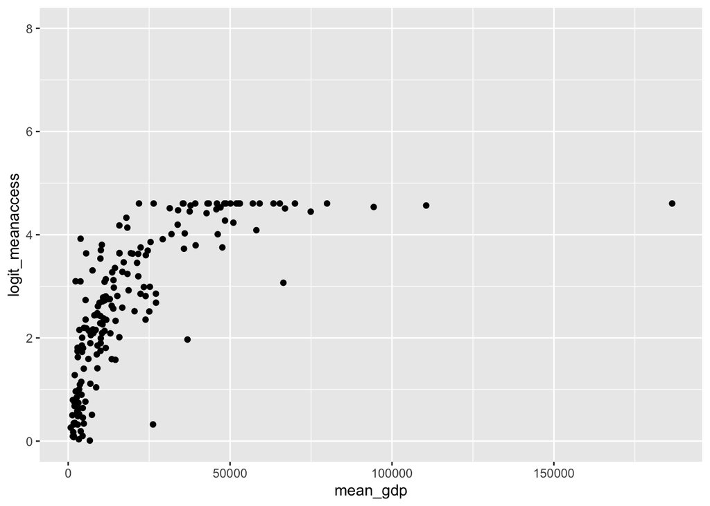

```r
# Adding newly generated observations to a dataset containing the original observed values
sim_data <- gdp_v_water_mean |>
  ungroup() |>
  filter(is.na(logit_meanaccess) == FALSE,
         is.na(mean_access) == FALSE
         ) |>
  select(mean_gdp, logit_meanaccess) |>
  bind_cols(sim_logit)

# Visualizing and comparing the simulation from our model to the original data
sim_data |>
  ggplot(aes(x = mean_gdp,
             y = logit_meanaccess
             )
         ) +
  geom_point() +
  scale_y_continuous(limits = c(0, 8))
```

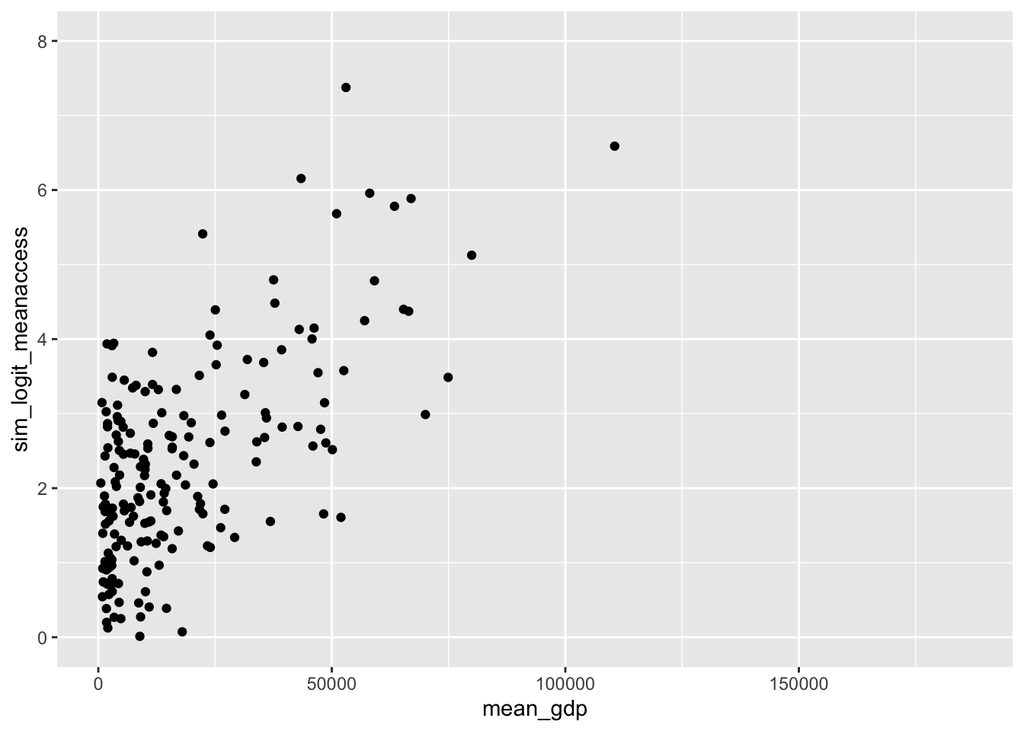

```r
sim_data |>
  ggplot(aes(x = mean_gdp,
             y = sim_logit_meanaccess
             )
         ) +
  geom_point() +
  scale_y_continuous(limits = c(0, 8))
```

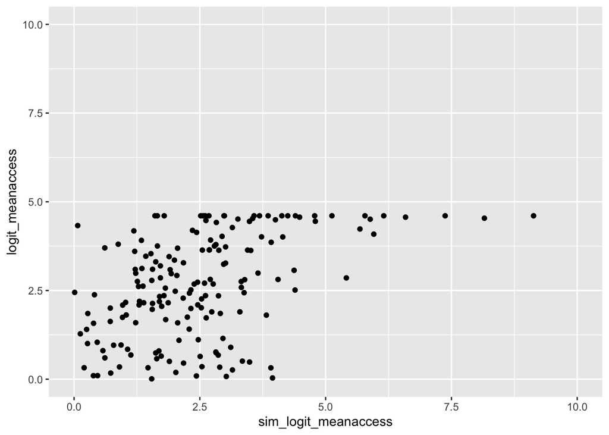

```r
sim_data |>
  ggplot(aes(x = sim_logit_meanaccess,
             y = logit_meanaccess),
         ) +
  geom_point() +
  scale_x_continuous(limits = c(0, 10)) +
  scale_y_continuous(limits = c(0, 10))
```

### 3.2 Generating Multiple Predictive Checks

```r
set.seed(7256)

# Generating 1000 simulated sets of observations and putting them into one dataset
nsims <- 10
sim_data2 <- map_dfc(.x = 1:nsims,
                     .f = ~ tibble(sim = addnoise(logit_predict,
                                                  sd = resid_sigma
                                                  )
                                   )
                     )

# Cleaning the simulated dataset
colnames(sim_data2) <- colnames(sim_data2) |>
  str_replace(pattern = "\\.\\.\\.",
              replace = "_"
              )

# Combining this simulated dataset with a dataset containing the original observed values
sim_data2 <- gdp_v_water_mean |>
  ungroup() |>
  filter(is.na(mean_gdp) == FALSE,
         is.na(logit_meanaccess) == FALSE
         ) |>
  select(logit_meanaccess) |>
  bind_cols(sim_data2)

head(sim_data)
```

```
# A tibble: 6 × 3
  mean_gdp logit_meanaccess sim_logit_meanaccess
     <dbl>            <dbl>                <dbl>
1    1688.           0.0770                3.03
2   10617.           2.26                  2.53
3   10891.           2.38                  0.406
4   57026.           4.61                  4.25
5    6690.           0.0102                1.54
6   19900            3.63                  2.88
```

```r
# Regressing observed values to each set of simulated values to generate r-squared values
reg_sim <- map(.x = sim_data2,
               .f = ~ lm(logit_meanaccess ~ .x,
                         data = sim_data2)
               ) |>
  map(.f = ~ glance(.x)) |>
  map_dbl(.f = ~ .x$r.squared)

# Removing the r-squared value corresponding to logit_meanaccess ~ logitmeanaccess
reg_sim <- reg_sim[names(reg_sim) != "logit_meanaccess"]
reg_sim
```

```
    sim_1     sim_2     sim_3     sim_4     sim_5     sim_6     sim_7     sim_8
0.2091420 0.2114854 0.2584789 0.2522831 0.2696088 0.1777289 0.1775799 0.2189434
    sim_9    sim_10
0.1953288 0.1354710
```

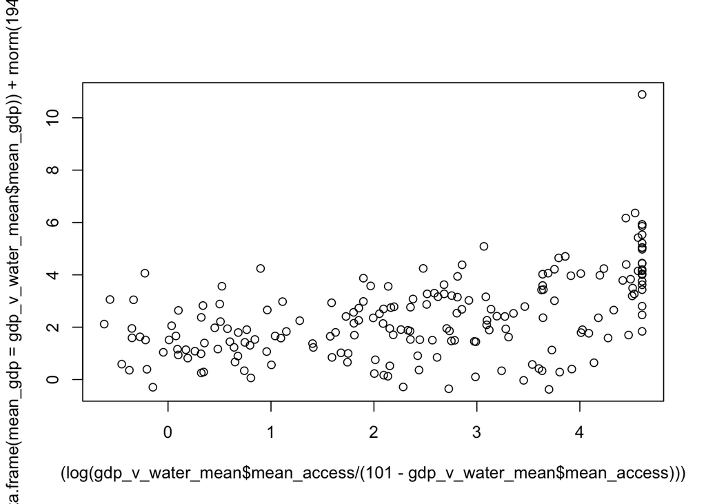

```r
plot(y = predict(model, newdata = data.frame(mean_gdp = gdp_v_water_mean$mean_gdp)) + rnorm(194, mean = 0, sd =  sigma(model)), x = (log(gdp_v_water_mean$mean_access / (101 - gdp_v_water_mean$mean_access))))
```